# Optimal Treatment Analysis

## Outcome Variable

**Outcome Variable:** haz

## Predictor Variables

**Intervention Variable:** hfoodsec

**Adjustment Set:**

- arm
- sex
- W_mage
- meducyrs
- feducyrs
- hhwealth_quart
- vagbrth
- W_nrooms
- W_nchldlt5
- brthmon
- W_parity
- impfloor
- impsan
- safeh20
- delta_W_mage
- delta_meducyrs
- delta_feducyrs
- delta_hhwealth_quart
- delta_vagbrth
- delta_W_nrooms
- delta_W_nchldlt5
- delta_brthmon
- delta_W_parity
- delta_impfloor
- delta_impsan
- delta_safeh20

## Stratifying Variables

The analysis was stratified on these variable(s):

- agecat
- studyid
- country

## Data Summary

| agecat | studyid | country | hfoodsec | n_cell | n |
| --- | --- | --- | --- | --- | --- |
| Birth | ki0047075b-MAL-ED | BANGLADESH | Food Secure | 157 | 188 |
| Birth | ki0047075b-MAL-ED | BANGLADESH | Mildly Food Insecure | 4 | 188 |
| Birth | ki0047075b-MAL-ED | BANGLADESH | Food Insecure | 27 | 188 |
| Birth | ki0047075b-MAL-ED | BRAZIL | Food Secure | 0 | 105 |
| Birth | ki0047075b-MAL-ED | BRAZIL | Mildly Food Insecure | 11 | 105 |
| Birth | ki0047075b-MAL-ED | BRAZIL | Food Insecure | 94 | 105 |
| Birth | ki0047075b-MAL-ED | INDIA | Food Secure | 154 | 170 |
| Birth | ki0047075b-MAL-ED | INDIA | Mildly Food Insecure | 2 | 170 |
| Birth | ki0047075b-MAL-ED | INDIA | Food Insecure | 14 | 170 |
| Birth | ki0047075b-MAL-ED | NEPAL | Food Secure | 76 | 98 |
| Birth | ki0047075b-MAL-ED | NEPAL | Mildly Food Insecure | 9 | 98 |
| Birth | ki0047075b-MAL-ED | NEPAL | Food Insecure | 13 | 98 |
| Birth | ki0047075b-MAL-ED | PERU | Food Secure | 27 | 107 |
| Birth | ki0047075b-MAL-ED | PERU | Mildly Food Insecure | 25 | 107 |
| Birth | ki0047075b-MAL-ED | PERU | Food Insecure | 55 | 107 |
| Birth | ki0047075b-MAL-ED | SOUTH AFRICA | Food Secure | 107 | 195 |
| Birth | ki0047075b-MAL-ED | SOUTH AFRICA | Mildly Food Insecure | 17 | 195 |
| Birth | ki0047075b-MAL-ED | SOUTH AFRICA | Food Insecure | 71 | 195 |
| Birth | ki1017093-NIH-Birth | BANGLADESH | Food Secure | 3 | 28 |
| Birth | ki1017093-NIH-Birth | BANGLADESH | Mildly Food Insecure | 21 | 28 |
| Birth | ki1017093-NIH-Birth | BANGLADESH | Food Insecure | 4 | 28 |
| Birth | ki1017093c-NIH-Crypto | BANGLADESH | Food Secure | 14 | 27 |
| Birth | ki1017093c-NIH-Crypto | BANGLADESH | Mildly Food Insecure | 9 | 27 |
| Birth | ki1017093c-NIH-Crypto | BANGLADESH | Food Insecure | 4 | 27 |
| Birth | kiGH5241-JiVitA-3 | BANGLADESH | Food Secure | 5997 | 12605 |
| Birth | kiGH5241-JiVitA-3 | BANGLADESH | Mildly Food Insecure | 4335 | 12605 |
| Birth | kiGH5241-JiVitA-3 | BANGLADESH | Food Insecure | 2273 | 12605 |
| Birth | kiGH5241-JiVitA-4 | BANGLADESH | Food Secure | 396 | 819 |
| Birth | kiGH5241-JiVitA-4 | BANGLADESH | Mildly Food Insecure | 309 | 819 |
| Birth | kiGH5241-JiVitA-4 | BANGLADESH | Food Insecure | 114 | 819 |

[output cut: 66 more lines]

The following strata were considered:

- agecat: 24 months, studyid: ki0047075b-MAL-ED, country: BANGLADESH
- agecat: 24 months, studyid: ki0047075b-MAL-ED, country: BRAZIL
- agecat: 24 months, studyid: ki0047075b-MAL-ED, country: INDIA
- agecat: 24 months, studyid: ki0047075b-MAL-ED, country: NEPAL
- agecat: 24 months, studyid: ki0047075b-MAL-ED, country: PERU
- agecat: 24 months, studyid: ki0047075b-MAL-ED, country: SOUTH AFRICA
- agecat: 24 months, studyid: ki1017093-NIH-Birth, country: BANGLADESH
- agecat: 24 months, studyid: ki1017093c-NIH-Crypto, country: BANGLADESH
- agecat: 24 months, studyid: ki1113344-GMS-Nepal, country: NEPAL
- agecat: 24 months, studyid: kiGH5241-JiVitA-3, country: BANGLADESH
- agecat: 24 months, studyid: kiGH5241-JiVitA-4, country: BANGLADESH
- agecat: 6 months, studyid: ki0047075b-MAL-ED, country: BANGLADESH
- agecat: 6 months, studyid: ki0047075b-MAL-ED, country: BRAZIL
- agecat: 6 months, studyid: ki0047075b-MAL-ED, country: INDIA
- agecat: 6 months, studyid: ki0047075b-MAL-ED, country: NEPAL
- agecat: 6 months, studyid: ki0047075b-MAL-ED, country: PERU
- agecat: 6 months, studyid: ki0047075b-MAL-ED, country: SOUTH AFRICA
- agecat: 6 months, studyid: ki1017093-NIH-Birth, country: BANGLADESH
- agecat: 6 months, studyid: ki1017093c-NIH-Crypto, country: BANGLADESH
- agecat: 6 months, studyid: ki1113344-GMS-Nepal, country: NEPAL
- agecat: 6 months, studyid: kiGH5241-JiVitA-3, country: BANGLADESH
- agecat: 6 months, studyid: kiGH5241-JiVitA-4, country: BANGLADESH
- agecat: Birth, studyid: ki0047075b-MAL-ED, country: BANGLADESH
- agecat: Birth, studyid: ki0047075b-MAL-ED, country: BRAZIL
- agecat: Birth, studyid: ki0047075b-MAL-ED, country: INDIA
- agecat: Birth, studyid: ki0047075b-MAL-ED, country: NEPAL
- agecat: Birth, studyid: ki0047075b-MAL-ED, country: PERU
- agecat: Birth, studyid: ki0047075b-MAL-ED, country: SOUTH AFRICA
- agecat: Birth, studyid: ki1017093-NIH-Birth, country: BANGLADESH
- agecat: Birth, studyid: ki1017093c-NIH-Crypto, country: BANGLADESH
- agecat: Birth, studyid: kiGH5241-JiVitA-3, country: BANGLADESH
- agecat: Birth, studyid: kiGH5241-JiVitA-4, country: BANGLADESH

### Dropped Strata

Some strata were dropped due to rare outcomes:

- agecat: Birth, studyid: ki0047075b-MAL-ED, country: BANGLADESH
- agecat: Birth, studyid: ki0047075b-MAL-ED, country: BRAZIL
- agecat: Birth, studyid: ki0047075b-MAL-ED, country: INDIA
- agecat: Birth, studyid: ki1017093-NIH-Birth, country: BANGLADESH
- agecat: Birth, studyid: ki1017093c-NIH-Crypto, country: BANGLADESH
- agecat: 6 months, studyid: ki0047075b-MAL-ED, country: BANGLADESH
- agecat: 6 months, studyid: ki0047075b-MAL-ED, country: BRAZIL
- agecat: 24 months, studyid: ki0047075b-MAL-ED, country: BANGLADESH
- agecat: 24 months, studyid: ki0047075b-MAL-ED, country: BRAZIL

## Methods Detail

We’re interested in the causal parameters $E[Y_a]$ for all values of $a \in \mathcal{A}$. These parameters represent the mean outcome if, possibly contrary to fact, we intervened to set all units to have $A=a$. Under the randomization and positivity assumptions, these are identified by the statistical parameters $\psi_a=E_W[E_{Y|A,W}(Y|A=a,W)]$. In addition, we’re interested in the mean of $Y$, $E[Y]$ under no intervention (the observed mean). We will estimate these parameters by using SuperLearner to fit the relevant likelihood factors – $E_{Y|A,W}(Y|A=a,W)$ and $p(A=a|W)$, and then updating our likelihood fit using a joint TMLE.

For unadjusted analyses ($W=\{\}$), initial likelihoods were estimated using Lrnr_glm to estimate the simple $E(Y|A)$ and Lrnr_mean to estimate $p(A)$. For adjusted analyses, a small library containing Lrnr_glmnet, Lrnr_xgboost, and Lrnr_mean was used.

Having estimated these parameters, we will then use the delta method to estimate relative risks and attributable risks relative to a prespecified baseline level of $A$.

# Results Detail

## Results Plots

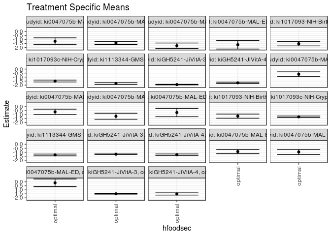

## Results Table

### Parameter: TSM

| agecat | studyid | country | intervention_level | baseline_level | estimate | ci_lower | ci_upper |
| --- | --- | --- | --- | --- | --- | --- | --- |
| Birth | ki0047075b-MAL-ED | NEPAL | optimal | observed | -0.9157444 | -1.1781108 | -0.6533780 |
| Birth | ki0047075b-MAL-ED | PERU | optimal | observed | -0.9660973 | -1.2785955 | -0.6535990 |
| Birth | ki0047075b-MAL-ED | SOUTH AFRICA | optimal | observed | -0.1290145 | -0.6092163 | 0.3511872 |
| Birth | kiGH5241-JiVitA-3 | BANGLADESH | optimal | observed | -1.4979591 | -1.5357199 | -1.4601983 |
| Birth | kiGH5241-JiVitA-4 | BANGLADESH | optimal | observed | -1.5143132 | -1.6527961 | -1.3758303 |
| 6 months | ki0047075b-MAL-ED | INDIA | optimal | observed | -0.6421668 | -0.9401094 | -0.3442242 |
| 6 months | ki0047075b-MAL-ED | NEPAL | optimal | observed | -0.6504001 | -0.9897525 | -0.3110476 |
| 6 months | ki0047075b-MAL-ED | PERU | optimal | observed | -1.1957485 | -1.5694903 | -0.8220068 |
| 6 months | ki0047075b-MAL-ED | SOUTH AFRICA | optimal | observed | -0.7341990 | -1.2600594 | -0.2083385 |
| 6 months | ki1017093-NIH-Birth | BANGLADESH | optimal | observed | -1.1811218 | -1.4403873 | -0.9218563 |
| 6 months | ki1017093c-NIH-Crypto | BANGLADESH | optimal | observed | -1.2670060 | -1.3637282 | -1.1702838 |
| 6 months | ki1113344-GMS-Nepal | NEPAL | optimal | observed | -1.3395255 | -1.4492662 | -1.2297848 |
| 6 months | kiGH5241-JiVitA-3 | BANGLADESH | optimal | observed | -1.2438968 | -1.2742440 | -1.2135497 |
| 6 months | kiGH5241-JiVitA-4 | BANGLADESH | optimal | observed | -1.3070986 | -1.3969462 | -1.2172511 |
| 24 months | ki0047075b-MAL-ED | INDIA | optimal | observed | -1.2177522 | -1.6441090 | -0.7913954 |
| 24 months | ki0047075b-MAL-ED | NEPAL | optimal | observed | -1.4341039 | -1.6302197 | -1.2379880 |
| 24 months | ki0047075b-MAL-ED | PERU | optimal | observed | -1.7791729 | -2.1185530 | -1.4397927 |
| 24 months | ki0047075b-MAL-ED | SOUTH AFRICA | optimal | observed | -1.6529650 | -2.1872147 | -1.1187153 |
| 24 months | ki1017093-NIH-Birth | BANGLADESH | optimal | observed | -1.5266834 | -1.7987115 | -1.2546553 |
| 24 months | ki1017093c-NIH-Crypto | BANGLADESH | optimal | observed | -1.4911694 | -1.6094094 | -1.3729294 |
| 24 months | ki1113344-GMS-Nepal | NEPAL | optimal | observed | -1.8053625 | -1.9044592 | -1.7062659 |
| 24 months | kiGH5241-JiVitA-3 | BANGLADESH | optimal | observed | -1.9383305 | -1.9775193 | -1.8991416 |
| 24 months | kiGH5241-JiVitA-4 | BANGLADESH | optimal | observed | -1.7173429 | -1.8044630 | -1.6302228 |

### Parameter: E(Y)

| agecat | studyid | country | intervention_level | baseline_level | estimate | ci_lower | ci_upper |
| --- | --- | --- | --- | --- | --- | --- | --- |
| Birth | ki0047075b-MAL-ED | NEPAL | observed | observed | -0.6804082 | -0.8755126 | -0.4853037 |
| Birth | ki0047075b-MAL-ED | PERU | observed | observed | -0.9387850 | -1.1159974 | -0.7615727 |
| Birth | ki0047075b-MAL-ED | SOUTH AFRICA | observed | observed | -0.6647692 | -0.8062103 | -0.5233282 |
| Birth | kiGH5241-JiVitA-3 | BANGLADESH | observed | observed | -1.5280452 | -1.5507110 | -1.5053794 |
| Birth | kiGH5241-JiVitA-4 | BANGLADESH | observed | observed | -1.5000733 | -1.5844715 | -1.4156751 |
| 6 months | ki0047075b-MAL-ED | INDIA | observed | observed | -1.2107862 | -1.3345960 | -1.0869764 |
| 6 months | ki0047075b-MAL-ED | NEPAL | observed | observed | -0.6253125 | -0.7752118 | -0.4754132 |
| 6 months | ki0047075b-MAL-ED | PERU | observed | observed | -1.3792042 | -1.5615886 | -1.1968198 |
| 6 months | ki0047075b-MAL-ED | SOUTH AFRICA | observed | observed | -1.0539803 | -1.1904887 | -0.9174718 |
| 6 months | ki1017093-NIH-Birth | BANGLADESH | observed | observed | -1.4073821 | -1.4960598 | -1.3187043 |
| 6 months | ki1017093c-NIH-Crypto | BANGLADESH | observed | observed | -1.1986783 | -1.2700937 | -1.1272630 |
| 6 months | ki1113344-GMS-Nepal | NEPAL | observed | observed | -1.3236269 | -1.4015413 | -1.2457125 |
| 6 months | kiGH5241-JiVitA-3 | BANGLADESH | observed | observed | -1.3131326 | -1.3362851 | -1.2899801 |
| 6 months | kiGH5241-JiVitA-4 | BANGLADESH | observed | observed | -1.3446891 | -1.3822219 | -1.3071564 |
| 24 months | ki0047075b-MAL-ED | INDIA | observed | observed | -1.8476415 | -1.9786652 | -1.7166178 |
| 24 months | ki0047075b-MAL-ED | NEPAL | observed | observed | -1.3776172 | -1.5402475 | -1.2149868 |
| 24 months | ki0047075b-MAL-ED | PERU | observed | observed | -1.7760748 | -1.9504595 | -1.6016900 |
| 24 months | ki0047075b-MAL-ED | SOUTH AFRICA | observed | observed | -1.6108333 | -1.7488019 | -1.4728648 |
| 24 months | ki1017093-NIH-Birth | BANGLADESH | observed | observed | -2.1807945 | -2.2835902 | -2.0779987 |
| 24 months | ki1017093c-NIH-Crypto | BANGLADESH | observed | observed | -1.4295331 | -1.5127726 | -1.3462935 |
| 24 months | ki1113344-GMS-Nepal | NEPAL | observed | observed | -1.8659973 | -1.9508504 | -1.7811442 |
| 24 months | kiGH5241-JiVitA-3 | BANGLADESH | observed | observed | -2.0089421 | -2.0368231 | -1.9810610 |
| 24 months | kiGH5241-JiVitA-4 | BANGLADESH | observed | observed | -1.7576915 | -1.7933270 | -1.7220560 |

### Parameter: PAR

| agecat | studyid | country | intervention_level | baseline_level | estimate | ci_lower | ci_upper |
| --- | --- | --- | --- | --- | --- | --- | --- |
| Birth | ki0047075b-MAL-ED | NEPAL | optimal | observed | 0.2353363 | -0.0248054 | 0.4954779 |
| Birth | ki0047075b-MAL-ED | PERU | optimal | observed | 0.0273122 | -0.2364298 | 0.2910542 |
| Birth | ki0047075b-MAL-ED | SOUTH AFRICA | optimal | observed | -0.5357547 | -1.0001243 | -0.0713851 |
| Birth | kiGH5241-JiVitA-3 | BANGLADESH | optimal | observed | -0.0300861 | -0.0608717 | 0.0006996 |
| Birth | kiGH5241-JiVitA-4 | BANGLADESH | optimal | observed | 0.0142399 | -0.0844630 | 0.1129429 |
| 6 months | ki0047075b-MAL-ED | INDIA | optimal | observed | -0.5686194 | -0.8850900 | -0.2521488 |
| 6 months | ki0047075b-MAL-ED | NEPAL | optimal | observed | 0.0250876 | -0.2569059 | 0.3070810 |
| 6 months | ki0047075b-MAL-ED | PERU | optimal | observed | -0.1834557 | -0.5061675 | 0.1392562 |
| 6 months | ki0047075b-MAL-ED | SOUTH AFRICA | optimal | observed | -0.3197813 | -0.8168394 | 0.1772767 |
| 6 months | ki1017093-NIH-Birth | BANGLADESH | optimal | observed | -0.2262603 | -0.4631769 | 0.0106564 |
| 6 months | ki1017093c-NIH-Crypto | BANGLADESH | optimal | observed | 0.0683277 | -0.0020405 | 0.1386959 |
| 6 months | ki1113344-GMS-Nepal | NEPAL | optimal | observed | 0.0158986 | -0.0736621 | 0.1054593 |
| 6 months | kiGH5241-JiVitA-3 | BANGLADESH | optimal | observed | -0.0692358 | -0.0881984 | -0.0502731 |
| 6 months | kiGH5241-JiVitA-4 | BANGLADESH | optimal | observed | -0.0375905 | -0.1220835 | 0.0469025 |
| 24 months | ki0047075b-MAL-ED | INDIA | optimal | observed | -0.6298893 | -1.0669555 | -0.1928231 |
| 24 months | ki0047075b-MAL-ED | NEPAL | optimal | observed | 0.0564867 | -0.1224858 | 0.2354592 |
| 24 months | ki0047075b-MAL-ED | PERU | optimal | observed | 0.0030981 | -0.3104932 | 0.3166894 |
| 24 months | ki0047075b-MAL-ED | SOUTH AFRICA | optimal | observed | 0.0421317 | -0.4506734 | 0.5349368 |
| 24 months | ki1017093-NIH-Birth | BANGLADESH | optimal | observed | -0.6541111 | -0.9017319 | -0.4064903 |
| 24 months | ki1017093c-NIH-Crypto | BANGLADESH | optimal | observed | 0.0616363 | -0.0268958 | 0.1501685 |
| 24 months | ki1113344-GMS-Nepal | NEPAL | optimal | observed | -0.0606347 | -0.1188957 | -0.0023738 |
| 24 months | kiGH5241-JiVitA-3 | BANGLADESH | optimal | observed | -0.0706116 | -0.0975880 | -0.0436351 |
| 24 months | kiGH5241-JiVitA-4 | BANGLADESH | optimal | observed | -0.0403486 | -0.1212698 | 0.0405726 |